# Resolvendo Sistemas Lineares no R com Solve

2021-02-11

Neste post vou mostrar como o R pode ser usado na Álgebra Linear, especificamente na resolução de Sistemas Lineares. Vou usar um exemplo simples e resolvê-lo com algumas funções do R base e com outras de pacotes adicionais. Os seguintes pacotes serão usados para este exemplo:

```r
# Pacotes necessários
library(tidyverse)
library(patchwork)
library(matlib)
```

O processo de resolução será bem simples, vou (i) escrever a matriz (pois em alguns problemas não será fornecida de maneira direta); (ii) escrever os coeficientes da matriz; (iii) criar variáveis no R com os coeficientes; (iv) testar se o sistema tem solução; (v) aplicar a função para resolvê-lo; (iv) plotar a solução em um gráfico.

### **Exercício 1**

1. Escrevendo a matriz (basta usar linguagem Latex):

```r
$$
\begin{bmatrix}
-5x & +2y & =3\\
9x & +y & =2
\end{bmatrix}
$$
```

$$\begin{bmatrix}
-5x & +2y & =3\\
9x & +y & =2
\end{bmatrix}$$
(ii) Escrevendo os coeficientes:
$$\begin{bmatrix}
-5 & 2 & = 3\\
9 & 1 & = 2
\end{bmatrix}$$
(iii) Criando as variáveis: Uma linha de cada vez e depos se indica o número de linhas com o **‘nrow’**.

```r
left_side <- matrix(c(-5,9, # linha 1
                      2,1), # linha 2
                 nrow = 2)

right_side <- matrix(c(3,2),
            nrow = 2)
```

4. Validando se há solução: Se retorna **TRUE** é porque há solução.

```r
all.equal(R(left_side), R(cbind(left_side,right_side)))
```

```
## [1] TRUE
```

22. Solucionando o sistema linear:

```r
solve(left_side,right_side)
```

```
##            [,1]
## [1,] 0.04347826
## [2,] 1.60869565
```

Os valores 0.0435 e 1.6087 indicam os valores de X e Y que geram a intersecção destas retas. Plotando o gráfico, a solução ficará mais evidente.

6. Visualização gráfica:

```
## -5*x[1] + 2*x[2]  =  3
##  9*x[1]   + x[2]  =  2
```

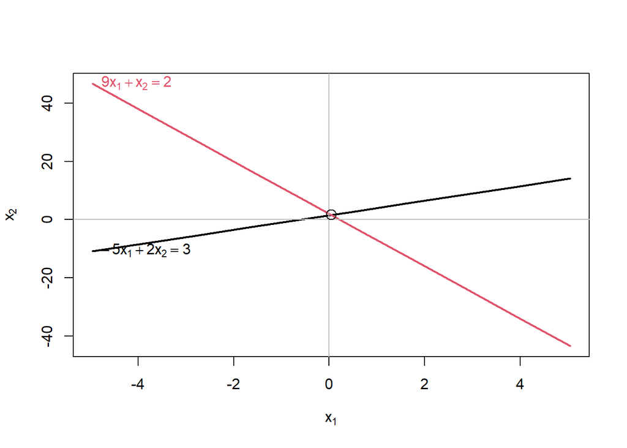

```r
matlib::plotEqn(left_side,right_side)
```

### **Exercício 2**

1. Escrevendo a matriz:

$$\begin{bmatrix}
1x & -1y & +2z & -1w & = -1\\
2x & +1y & -2z & -2w & = -2\\
-1x & +2y & -4z & +1w & = 1\\
3x & +0y & +0z & -3w & = -3
\end{bmatrix}$$
(ii) Escrevendo os coeficientes:
$$\begin{bmatrix}
1 & -1 & +2 & -1 & = -1\\
2 & +1 & -2 & -2 & = -2\\
-1 & +2 & -4 & +1 & = 1\\
3 & +0 & +0 & -3 & = -3
\end{bmatrix}$$
(iii) Criando as variáveis:

```r
left_side <- matrix(c(1,2,-1,3,
                      -1,1,2,0,
                      2,-2,-4,0,
                      -1,-2,1,-3),
                 nrow = 4)

right_side <- matrix(c(-1,-2,1,-3),
            nrow = 4)
```

4. Validando se há solução: Se retorna **TRUE** é porque há solução.

```r
all.equal(R(left_side), R(cbind(left_side,right_side)))
```

```
## [1] TRUE
```

22. Solucionando o sistema linear:

```r
#solve(left_side,right_side)
```

```r
det(left_side)
```

```
## [1] 0
```